# Project: Wrangling and Analyze Data

```python
import pandas as pd
import numpy as np
import requests
import matplotlib.pyplot as plt
import seaborn as sb
```

## Data Gathering

In the cell below, gather **all** three pieces of data for this project and load them in the notebook. **Note:** the methods required to gather each data are different.

1. Directly download the WeRateDogs Twitter archive data (twitter_archive_enhanced.csv)

```python
#Download twitter-archive-enhanced using read_csv pandas's method
twitter_archive = pd.read_csv('twitter-archive-enhanced.csv')
#View the first couple of rows
twitter_archive.head()
```

|  | tweet_id | in_reply_to_status_id | in_reply_to_user_id | timestamp | source | text | retweeted_status_id | retweeted_status_user_id | retweeted_status_timestamp | expanded_urls | rating_numerator | rating_denominator | name | doggo | floofer | pupper | puppo |
| --- | --- | --- | --- | --- | --- | --- | --- | --- | --- | --- | --- | --- | --- | --- | --- | --- | --- |
| 0 | 892420643555336193 | NaN | NaN | 2017-08-01 16:23:56 +0000 | <a href="http://twitter.com/download/iphone" r... | This is Phineas. He's a mystical boy. Only eve... | NaN | NaN | NaN | https://twitter.com/dog_rates/status/892420643... | 13 | 10 | Phineas | None | None | None | None |
| 1 | 892177421306343426 | NaN | NaN | 2017-08-01 00:17:27 +0000 | <a href="http://twitter.com/download/iphone" r... | This is Tilly. She's just checking pup on you.... | NaN | NaN | NaN | https://twitter.com/dog_rates/status/892177421... | 13 | 10 | Tilly | None | None | None | None |
| 2 | 891815181378084864 | NaN | NaN | 2017-07-31 00:18:03 +0000 | <a href="http://twitter.com/download/iphone" r... | This is Archie. He is a rare Norwegian Pouncin... | NaN | NaN | NaN | https://twitter.com/dog_rates/status/891815181... | 12 | 10 | Archie | None | None | None | None |
| 3 | 891689557279858688 | NaN | NaN | 2017-07-30 15:58:51 +0000 | <a href="http://twitter.com/download/iphone" r... | This is Darla. She commenced a snooze mid meal... | NaN | NaN | NaN | https://twitter.com/dog_rates/status/891689557... | 13 | 10 | Darla | None | None | None | None |
| 4 | 891327558926688256 | NaN | NaN | 2017-07-29 16:00:24 +0000 | <a href="http://twitter.com/download/iphone" r... | This is Franklin. He would like you to stop ca... | NaN | NaN | NaN | https://twitter.com/dog_rates/status/891327558... | 12 | 10 | Franklin | None | None | None | None |

1. Use the Requests library to download the tweet image prediction (image_predictions.tsv)

```python
#first save the url link
url = "https://d17h27t6h515a5.cloudfront.net/topher/2017/August/599fd2ad_image-predictions/image-predictions.tsv"
response = requests.get(url)
with open('image_predictions.tsv', 'wb') as file:
    file.write(response.content)
image_predictions = pd.read_csv('image_predictions.tsv', sep='\t')
#View the first couple of lines in image_predictions data
image_predictions.head()
```

|  | tweet_id | jpg_url | img_num | p1 | p1_conf | p1_dog | p2 | p2_conf | p2_dog | p3 | p3_conf | p3_dog |
| --- | --- | --- | --- | --- | --- | --- | --- | --- | --- | --- | --- | --- |
| 0 | 666020888022790149 | https://pbs.twimg.com/media/CT4udn0WwAA0aMy.jpg | 1 | Welsh_springer_spaniel | 0.465074 | True | collie | 0.156665 | True | Shetland_sheepdog | 0.061428 | True |
| 1 | 666029285002620928 | https://pbs.twimg.com/media/CT42GRgUYAA5iDo.jpg | 1 | redbone | 0.506826 | True | miniature_pinscher | 0.074192 | True | Rhodesian_ridgeback | 0.072010 | True |
| 2 | 666033412701032449 | https://pbs.twimg.com/media/CT4521TWwAEvMyu.jpg | 1 | German_shepherd | 0.596461 | True | malinois | 0.138584 | True | bloodhound | 0.116197 | True |
| 3 | 666044226329800704 | https://pbs.twimg.com/media/CT5Dr8HUEAA-lEu.jpg | 1 | Rhodesian_ridgeback | 0.408143 | True | redbone | 0.360687 | True | miniature_pinscher | 0.222752 | True |
| 4 | 666049248165822465 | https://pbs.twimg.com/media/CT5IQmsXIAAKY4A.jpg | 1 | miniature_pinscher | 0.560311 | True | Rottweiler | 0.243682 | True | Doberman | 0.154629 | True |

1. Use the Tweepy library to query additional data via the Twitter API (tweet_json.txt)

```python
#Reading the json file by using read_json pandas's method
tweet_json = pd.read_json('tweet-json.txt',lines=True)
#View the first 4 rows
tweet_json.head(4)
```

|  | contributors | coordinates | created_at | display_text_range | entities | extended_entities | favorite_count | favorited | full_text | geo | ... | possibly_sensitive_appealable | quoted_status | quoted_status_id | quoted_status_id_str | retweet_count | retweeted | retweeted_status | source | truncated | user |
| --- | --- | --- | --- | --- | --- | --- | --- | --- | --- | --- | --- | --- | --- | --- | --- | --- | --- | --- | --- | --- | --- |
| 0 | NaN | NaN | 2017-08-01 16:23:56 | [0, 85] | {'hashtags': [], 'symbols': [], 'user_mentions... | {'media': [{'id': 892420639486877696, 'id_str'... | 39467 | False | This is Phineas. He's a mystical boy. Only eve... | NaN | ... | 0.0 | NaN | NaN | NaN | 8853 | False | NaN | <a href="http://twitter.com/download/iphone" r... | False | {'id': 4196983835, 'id_str': '4196983835', 'na... |
| 1 | NaN | NaN | 2017-08-01 00:17:27 | [0, 138] | {'hashtags': [], 'symbols': [], 'user_mentions... | {'media': [{'id': 892177413194625024, 'id_str'... | 33819 | False | This is Tilly. She's just checking pup on you.... | NaN | ... | 0.0 | NaN | NaN | NaN | 6514 | False | NaN | <a href="http://twitter.com/download/iphone" r... | False | {'id': 4196983835, 'id_str': '4196983835', 'na... |
| 2 | NaN | NaN | 2017-07-31 00:18:03 | [0, 121] | {'hashtags': [], 'symbols': [], 'user_mentions... | {'media': [{'id': 891815175371796480, 'id_str'... | 25461 | False | This is Archie. He is a rare Norwegian Pouncin... | NaN | ... | 0.0 | NaN | NaN | NaN | 4328 | False | NaN | <a href="http://twitter.com/download/iphone" r... | False | {'id': 4196983835, 'id_str': '4196983835', 'na... |
| 3 | NaN | NaN | 2017-07-30 15:58:51 | [0, 79] | {'hashtags': [], 'symbols': [], 'user_mentions... | {'media': [{'id': 891689552724799489, 'id_str'... | 42908 | False | This is Darla. She commenced a snooze mid meal... | NaN | ... | 0.0 | NaN | NaN | NaN | 8964 | False | NaN | <a href="http://twitter.com/download/iphone" r... | False | {'id': 4196983835, 'id_str': '4196983835', 'na... |

4 rows × 31 columns

## Assessing Data

In this section, detect and document at least **eight (8) quality issues and two (2) tidiness issue**. You must use **both** visual assessment programmatic assessement to assess the data.

**Note:** pay attention to the following key points when you access the data.

- You only want original ratings (no retweets) that have images. Though there are 5000+ tweets in the dataset, not all are dog ratings and some are retweets.
- Assessing and cleaning the entire dataset completely would require a lot of time, and is not necessary to practice and demonstrate your skills in data wrangling. Therefore, the requirements of this project are only to assess and clean at least 8 quality issues and at least 2 tidiness issues in this dataset.
- The fact that the rating numerators are greater than the denominators does not need to be cleaned. This [unique rating system](http://knowyourmeme.com/memes/theyre-good-dogs-brent) is a big part of the popularity of WeRateDogs.
- You do not need to gather the tweets beyond August 1st, 2017. You can, but note that you won't be able to gather the image predictions for these tweets since you don't have access to the algorithm used.

### Quality issues

1.**twitter_archive:** timestamp as object (string), needs to be converted to DateTime datatype.

2.**twitter_archive:** tweet_id as int64, needs to be converted to String datatype.

3.**twitter_archive:** deals with records that has a denomiator higher than 10.

4.**twitter_archive:** data in source column has a href html tag, needs to be fixed.

5.**twitter_archive:** delete all retweeted tweets 'duplicate tweets'.

### Tidiness issues

1.**twitter_archive:** doggo, floofer, pupper and puppo needs to be in one column rather than 4."Each variable is a column"

2.**twitter_archive:** remove unnecessary columns(in_reply_to_status_id, in_reply_to_user_id, retweeted_status_id, retweeted_status_user_id, retweeted_status_timestamp)

## Assesing || twitter_archive dataset

```python
#check the datatype of twitter archive df
twitter_archive.info()
```

```
<class 'pandas.core.frame.DataFrame'>
RangeIndex: 2356 entries, 0 to 2355
Data columns (total 17 columns):
tweet_id                      2356 non-null int64
in_reply_to_status_id         78 non-null float64
in_reply_to_user_id           78 non-null float64
timestamp                     2356 non-null object
source                        2356 non-null object
text                          2356 non-null object
retweeted_status_id           181 non-null float64
retweeted_status_user_id      181 non-null float64
retweeted_status_timestamp    181 non-null object
expanded_urls                 2297 non-null object
rating_numerator              2356 non-null int64
rating_denominator            2356 non-null int64
name                          2356 non-null object
doggo                         2356 non-null object
floofer                       2356 non-null object
pupper                        2356 non-null object
puppo                         2356 non-null object
dtypes: float64(4), int64(3), object(10)
memory usage: 313.0+ KB
```

```python
#View all record that has a denomiator higher than 10 which not right according to the documentation of the dataset
twitter_archive.rating_denominator.value_counts()
#As we can see the is a couple of records that has a denomiator higher, will try to
#fix it or delete it if neccassery
```

```
10     2333
11        3
50        3
80        2
20        2
2         1
16        1
40        1
70        1
15        1
90        1
110       1
120       1
130       1
150       1
170       1
7         1
0         1
Name: rating_denominator, dtype: int64
```

```python
#query tweets with denominator higher that 10.
high_deno= twitter_archive.query('rating_denominator >10')
high_deno
```

|  | tweet_id | in_reply_to_status_id | in_reply_to_user_id | timestamp | source | text | retweeted_status_id | retweeted_status_user_id | retweeted_status_timestamp | expanded_urls | rating_numerator | rating_denominator | name | doggo | floofer | pupper | puppo |
| --- | --- | --- | --- | --- | --- | --- | --- | --- | --- | --- | --- | --- | --- | --- | --- | --- | --- |
| 342 | 832088576586297345 | 8.320875e+17 | 3.058208e+07 | 2017-02-16 04:45:50 +0000 | <a href="http://twitter.com/download/iphone" r... | @docmisterio account started on 11/15/15 | NaN | NaN | NaN | NaN | 11 | 15 | None | None | None | None | None |
| 433 | 820690176645140481 | NaN | NaN | 2017-01-15 17:52:40 +0000 | <a href="http://twitter.com/download/iphone" r... | The floofs have been released I repeat the flo... | NaN | NaN | NaN | https://twitter.com/dog_rates/status/820690176... | 84 | 70 | None | None | None | None | None |
| 784 | 775096608509886464 | NaN | NaN | 2016-09-11 22:20:06 +0000 | <a href="http://twitter.com/download/iphone" r... | RT @dog_rates: After so many requests, this is... | 7.403732e+17 | 4.196984e+09 | 2016-06-08 02:41:38 +0000 | https://twitter.com/dog_rates/status/740373189... | 9 | 11 | None | None | None | None | None |
| 902 | 758467244762497024 | NaN | NaN | 2016-07-28 01:00:57 +0000 | <a href="http://twitter.com/download/iphone" r... | Why does this never happen at my front door...... | NaN | NaN | NaN | https://twitter.com/dog_rates/status/758467244... | 165 | 150 | None | None | None | None | None |
| 1068 | 740373189193256964 | NaN | NaN | 2016-06-08 02:41:38 +0000 | <a href="http://twitter.com/download/iphone" r... | After so many requests, this is Bretagne. She ... | NaN | NaN | NaN | https://twitter.com/dog_rates/status/740373189... | 9 | 11 | None | None | None | None | None |
| 1120 | 731156023742988288 | NaN | NaN | 2016-05-13 16:15:54 +0000 | <a href="http://twitter.com/download/iphone" r... | Say hello to this unbelievably well behaved sq... | NaN | NaN | NaN | https://twitter.com/dog_rates/status/731156023... | 204 | 170 | this | None | None | None | None |
| 1165 | 722974582966214656 | NaN | NaN | 2016-04-21 02:25:47 +0000 | <a href="http://twitter.com/download/iphone" r... | Happy 4/20 from the squad! 13/10 for all https... | NaN | NaN | NaN | https://twitter.com/dog_rates/status/722974582... | 4 | 20 | None | None | None | None | None |
| 1202 | 716439118184652801 | NaN | NaN | 2016-04-03 01:36:11 +0000 | <a href="http://twitter.com/download/iphone" r... | This is Bluebert. He just saw that both #Final... | NaN | NaN | NaN | https://twitter.com/dog_rates/status/716439118... | 50 | 50 | Bluebert | None | None | None | None |
| 1228 | 713900603437621249 | NaN | NaN | 2016-03-27 01:29:02 +0000 | <a href="http://twitter.com/download/iphone" r... | Happy Saturday here's 9 puppers on a bench. 99... | NaN | NaN | NaN | https://twitter.com/dog_rates/status/713900603... | 99 | 90 | None | None | None | None | None |
| 1254 | 710658690886586372 | NaN | NaN | 2016-03-18 02:46:49 +0000 | <a href="http://twitter.com/download/iphone" r... | Here's a brigade of puppers. All look very pre... | NaN | NaN | NaN | https://twitter.com/dog_rates/status/710658690... | 80 | 80 | None | None | None | None | None |
| 1274 | 709198395643068416 | NaN | NaN | 2016-03-14 02:04:08 +0000 | <a href="http://twitter.com/download/iphone" r... | From left to right:\nCletus, Jerome, Alejandro... | NaN | NaN | NaN | https://twitter.com/dog_rates/status/709198395... | 45 | 50 | None | None | None | None | None |
| 1351 | 704054845121142784 | NaN | NaN | 2016-02-28 21:25:30 +0000 | <a href="http://twitter.com/download/iphone" r... | Here is a whole flock of puppers. 60/50 I'll ... | NaN | NaN | NaN | https://twitter.com/dog_rates/status/704054845... | 60 | 50 | a | None | None | None | None |
| 1433 | 697463031882764288 | NaN | NaN | 2016-02-10 16:51:59 +0000 | <a href="http://twitter.com/download/iphone" r... | Happy Wednesday here's a bucket of pups. 44/40... | NaN | NaN | NaN | https://twitter.com/dog_rates/status/697463031... | 44 | 40 | None | None | None | None | None |
| 1598 | 686035780142297088 | 6.860340e+17 | 4.196984e+09 | 2016-01-10 04:04:10 +0000 | <a href="http://twitter.com/download/iphone" r... | Yes I do realize a rating of 4/20 would've bee... | NaN | NaN | NaN | NaN | 4 | 20 | None | None | None | None | None |
| 1634 | 684225744407494656 | 6.842229e+17 | 4.196984e+09 | 2016-01-05 04:11:44 +0000 | <a href="http://twitter.com/download/iphone" r... | Two sneaky puppers were not initially seen, mo... | NaN | NaN | NaN | https://twitter.com/dog_rates/status/684225744... | 143 | 130 | None | None | None | None | None |
| 1635 | 684222868335505415 | NaN | NaN | 2016-01-05 04:00:18 +0000 | <a href="http://twitter.com/download/iphone" r... | Someone help the girl is being mugged. Several... | NaN | NaN | NaN | https://twitter.com/dog_rates/status/684222868... | 121 | 110 | None | None | None | None | None |
| 1662 | 682962037429899265 | NaN | NaN | 2016-01-01 16:30:13 +0000 | <a href="http://twitter.com/download/iphone" r... | This is Darrel. He just robbed a 7/11 and is i... | NaN | NaN | NaN | https://twitter.com/dog_rates/status/682962037... | 7 | 11 | Darrel | None | None | None | None |
| 1663 | 682808988178739200 | 6.827884e+17 | 4.196984e+09 | 2016-01-01 06:22:03 +0000 | <a href="http://twitter.com/download/iphone" r... | I'm aware that I could've said 20/16, but here... | NaN | NaN | NaN | NaN | 20 | 16 | None | None | None | None | None |
| 1779 | 677716515794329600 | NaN | NaN | 2015-12-18 05:06:23 +0000 | <a href="http://twitter.com/download/iphone" r... | IT'S PUPPERGEDDON. Total of 144/120 ...I think... | NaN | NaN | NaN | https://twitter.com/dog_rates/status/677716515... | 144 | 120 | None | None | None | None | None |
| 1843 | 675853064436391936 | NaN | NaN | 2015-12-13 01:41:41 +0000 | <a href="http://twitter.com/download/iphone" r... | Here we have an entire platoon of puppers. Tot... | NaN | NaN | NaN | https://twitter.com/dog_rates/status/675853064... | 88 | 80 | None | None | None | None | None |

```python
tweet_id= high_deno['tweet_id']
text= high_deno['text']

for point in zip(tweet_id, text):
    print("tweet Id:{} \n text: {} \n ----------------".format(*point))
```

```
tweet Id:832088576586297345
 text: @docmisterio account started on 11/15/15
 ----------------
tweet Id:820690176645140481
 text: The floofs have been released I repeat the floofs have been released. 84/70 https://t.co/NIYC820tmd
 ----------------
tweet Id:775096608509886464
 text: RT @dog_rates: After so many requests, this is Bretagne. She was the last surviving 9/11 search dog, and our second ever 14/10. RIP https:/…
 ----------------
tweet Id:758467244762497024
 text: Why does this never happen at my front door... 165/150 https://t.co/HmwrdfEfUE
 ----------------
tweet Id:740373189193256964
 text: After so many requests, this is Bretagne. She was the last surviving 9/11 search dog, and our second ever 14/10. RIP https://t.co/XAVDNDaVgQ
 ----------------
tweet Id:731156023742988288
 text: Say hello to this unbelievably well behaved squad of doggos. 204/170 would try to pet all at once https://t.co/yGQI3He3xv
 ----------------
tweet Id:722974582966214656
 text: Happy 4/20 from the squad! 13/10 for all https://t.co/eV1diwds8a
 ----------------
tweet Id:716439118184652801
 text: This is Bluebert. He just saw that both #FinalFur match ups are split 50/50. Amazed af. 11/10 https://t.co/Kky1DPG4iq
 ----------------
tweet Id:713900603437621249
 text: Happy Saturday here's 9 puppers on a bench. 99/90 good work everybody https://t.co/mpvaVxKmc1
 ----------------
tweet Id:710658690886586372
 text: Here's a brigade of puppers. All look very prepared for whatever happens next. 80/80 https://t.co/0eb7R1Om12
 ----------------
tweet Id:709198395643068416
 text: From left to right:
Cletus, Jerome, Alejandro, Burp, &amp; Titson
None know where camera is. 45/50 would hug all at once https://t.co/sedre1ivTK
 ----------------
tweet Id:704054845121142784
 text: Here is a whole flock of puppers.  60/50 I'll take the lot https://t.co/9dpcw6MdWa
 ----------------
tweet Id:697463031882764288
 text: Happy Wednesday here's a bucket of pups. 44/40 would pet all at once https://t.co/HppvrYuamZ
 ----------------
tweet Id:686035780142297088
 text: Yes I do realize a rating of 4/20 would've been fitting. However, it would be unjust to give these cooperative pups that low of a rating
 ----------------
tweet Id:684225744407494656
 text: Two sneaky puppers were not initially seen, moving the rating to 143/130. Please forgive us. Thank you https://t.co/kRK51Y5ac3
 ----------------
tweet Id:684222868335505415
 text: Someone help the girl is being mugged. Several are distracting her while two steal her shoes. Clever puppers 121/110 https://t.co/1zfnTJLt55
 ----------------
tweet Id:682962037429899265
 text: This is Darrel. He just robbed a 7/11 and is in a high speed police chase. Was just spotted by the helicopter 10/10 https://t.co/7EsP8LmSp5
 ----------------
tweet Id:682808988178739200
 text: I'm aware that I could've said 20/16, but here at WeRateDogs we are very professional. An inconsistent rating scale is simply irresponsible
 ----------------
tweet Id:677716515794329600
 text: IT'S PUPPERGEDDON. Total of 144/120 ...I think https://t.co/ZanVtAtvIq
 ----------------
tweet Id:675853064436391936
 text: Here we have an entire platoon of puppers. Total score: 88/80 would pet all at once https://t.co/y93p6FLvVw
 ----------------
```

- **Tweet Id** 832088576586297345: This tweet needs to be deleted, no rating provided.
- **Tweet Id** 820690176645140481: Wrong rating provided, needs to be deleted.
- **Tweet Id** 775096608509886464: I've noticed that this a retweeted tweet for tweet with index **740373189193256964**, need to delete all retweeted tweets since its a duplicate ones.
- **Tweet Id** 758467244762497024: Wrong rating provided, needs to be deleted.
- **Tweet Id** 740373189193256964: Wrong captured data from tweet, actual rating is 14/10.
- **Tweet Id** 731156023742988288: Wrong rating provided, needs to be deleted.
- **Tweet Id** 722974582966214656: Wrong data captured, actual rating is 13/10.
- **Tweet Id** 716439118184652801: Wrong data captured, actual rating is 11/10.
- **Tweet Id** 713900603437621249: Wrong rating provided, needs to be deleted.
- **Tweet Id** 710658690886586372: rating can be change to 10/10 since it same as 80/80.
- **Tweet Id** 709198395643068416: Wrong rating provided, needs to be deleted.
- **Tweet Id** 704054845121142784: Wrong rating provided, needs to be deleted.
- **Tweet Id** 697463031882764288: Wrong rating provided, needs to be deleted.
- **Tweet Id** 686035780142297088: Wrong rating provided, needs to be deleted.
- **Tweet Id** 684225744407494656: Wrong rating provided, needs to be deleted.
- **Tweet Id** 684222868335505415: Wrong rating provided, needs to be deleted.
- **Tweet Id** 682962037429899265:tweet isn't clear for me, I guess the acutal rating is 10/10 not 7/11
- **Tweet Id** 682808988178739200:Wrong rating provided, needs to be deleted.
- **Tweet Id** 677716515794329600:Wrong rating provided, needs to be deleted.
- **Tweet Id** 675853064436391936:Wrong rating provided, needs to be deleted.

```python
#Checkif there is any duplicated values
twitter_archive.duplicated().sum()
```

```
0
```

## Assesing2 || image_predictions dataset

### Quality issues

1.**image_predictions:** Remove duplicate jpg_url.

2.**image_predicitons:** Change datatype of tweet_id column

### Tidness issues

1.**image_prediction:** extract the breed of dog from the p,p_conf and p_dog columns.

```python
#check datatypes of columns
image_predictions.info()
```

```
<class 'pandas.core.frame.DataFrame'>
RangeIndex: 2075 entries, 0 to 2074
Data columns (total 12 columns):
tweet_id    2075 non-null int64
jpg_url     2075 non-null object
img_num     2075 non-null int64
p1          2075 non-null object
p1_conf     2075 non-null float64
p1_dog      2075 non-null bool
p2          2075 non-null object
p2_conf     2075 non-null float64
p2_dog      2075 non-null bool
p3          2075 non-null object
p3_conf     2075 non-null float64
p3_dog      2075 non-null bool
dtypes: bool(3), float64(3), int64(2), object(4)
memory usage: 152.1+ KB
```

```python
#check for duplicate reocrds.
image_predictions.duplicated().sum()
```

```
0
```

```python
#check for duplicate jpg_url since the prediction is based on it.
image_predictions['jpg_url'].duplicated().sum()
#there is 66 duplicate photo that has to be deleted.
```

```
66
```

```python
image_predictions.describe()
```

|  | tweet_id | img_num | p1_conf | p2_conf | p3_conf |
| --- | --- | --- | --- | --- | --- |
| count | 2.075000e+03 | 2075.000000 | 2075.000000 | 2.075000e+03 | 2.075000e+03 |
| mean | 7.384514e+17 | 1.203855 | 0.594548 | 1.345886e-01 | 6.032417e-02 |
| std | 6.785203e+16 | 0.561875 | 0.271174 | 1.006657e-01 | 5.090593e-02 |
| min | 6.660209e+17 | 1.000000 | 0.044333 | 1.011300e-08 | 1.740170e-10 |
| 25% | 6.764835e+17 | 1.000000 | 0.364412 | 5.388625e-02 | 1.622240e-02 |
| 50% | 7.119988e+17 | 1.000000 | 0.588230 | 1.181810e-01 | 4.944380e-02 |
| 75% | 7.932034e+17 | 1.000000 | 0.843855 | 1.955655e-01 | 9.180755e-02 |
| max | 8.924206e+17 | 4.000000 | 1.000000 | 4.880140e-01 | 2.734190e-01 |

## Assesing3 || tweet_json dataset

### Quality issues

1.**tweet_json:** rename "id" column to tweet_id and change datatype to String.

2.**tweet_json:** remove href tag from source column.

### Tidness issues

1.**tweet_json:** We only need favorite_count, retweet count,id "tweet_id" (after renamed), and source columns.

```python
tweet_json.head(5)
```

|  | contributors | coordinates | created_at | display_text_range | entities | extended_entities | favorite_count | favorited | full_text | geo | ... | possibly_sensitive_appealable | quoted_status | quoted_status_id | quoted_status_id_str | retweet_count | retweeted | retweeted_status | source | truncated | user |
| --- | --- | --- | --- | --- | --- | --- | --- | --- | --- | --- | --- | --- | --- | --- | --- | --- | --- | --- | --- | --- | --- |
| 0 | NaN | NaN | 2017-08-01 16:23:56 | [0, 85] | {'hashtags': [], 'symbols': [], 'user_mentions... | {'media': [{'id': 892420639486877696, 'id_str'... | 39467 | False | This is Phineas. He's a mystical boy. Only eve... | NaN | ... | 0.0 | NaN | NaN | NaN | 8853 | False | NaN | <a href="http://twitter.com/download/iphone" r... | False | {'id': 4196983835, 'id_str': '4196983835', 'na... |
| 1 | NaN | NaN | 2017-08-01 00:17:27 | [0, 138] | {'hashtags': [], 'symbols': [], 'user_mentions... | {'media': [{'id': 892177413194625024, 'id_str'... | 33819 | False | This is Tilly. She's just checking pup on you.... | NaN | ... | 0.0 | NaN | NaN | NaN | 6514 | False | NaN | <a href="http://twitter.com/download/iphone" r... | False | {'id': 4196983835, 'id_str': '4196983835', 'na... |
| 2 | NaN | NaN | 2017-07-31 00:18:03 | [0, 121] | {'hashtags': [], 'symbols': [], 'user_mentions... | {'media': [{'id': 891815175371796480, 'id_str'... | 25461 | False | This is Archie. He is a rare Norwegian Pouncin... | NaN | ... | 0.0 | NaN | NaN | NaN | 4328 | False | NaN | <a href="http://twitter.com/download/iphone" r... | False | {'id': 4196983835, 'id_str': '4196983835', 'na... |
| 3 | NaN | NaN | 2017-07-30 15:58:51 | [0, 79] | {'hashtags': [], 'symbols': [], 'user_mentions... | {'media': [{'id': 891689552724799489, 'id_str'... | 42908 | False | This is Darla. She commenced a snooze mid meal... | NaN | ... | 0.0 | NaN | NaN | NaN | 8964 | False | NaN | <a href="http://twitter.com/download/iphone" r... | False | {'id': 4196983835, 'id_str': '4196983835', 'na... |
| 4 | NaN | NaN | 2017-07-29 16:00:24 | [0, 138] | {'hashtags': [{'text': 'BarkWeek', 'indices': ... | {'media': [{'id': 891327551943041024, 'id_str'... | 41048 | False | This is Franklin. He would like you to stop ca... | NaN | ... | 0.0 | NaN | NaN | NaN | 9774 | False | NaN | <a href="http://twitter.com/download/iphone" r... | False | {'id': 4196983835, 'id_str': '4196983835', 'na... |

5 rows × 31 columns

```python
tweet_json.info()
```

```
<class 'pandas.core.frame.DataFrame'>
RangeIndex: 2354 entries, 0 to 2353
Data columns (total 31 columns):
contributors                     0 non-null float64
coordinates                      0 non-null float64
created_at                       2354 non-null datetime64[ns]
display_text_range               2354 non-null object
entities                         2354 non-null object
extended_entities                2073 non-null object
favorite_count                   2354 non-null int64
favorited                        2354 non-null bool
full_text                        2354 non-null object
geo                              0 non-null float64
id                               2354 non-null int64
id_str                           2354 non-null int64
in_reply_to_screen_name          78 non-null object
in_reply_to_status_id            78 non-null float64
in_reply_to_status_id_str        78 non-null float64
in_reply_to_user_id              78 non-null float64
in_reply_to_user_id_str          78 non-null float64
is_quote_status                  2354 non-null bool
lang                             2354 non-null object
place                            1 non-null object
possibly_sensitive               2211 non-null float64
possibly_sensitive_appealable    2211 non-null float64
quoted_status                    28 non-null object
quoted_status_id                 29 non-null float64
quoted_status_id_str             29 non-null float64
retweet_count                    2354 non-null int64
retweeted                        2354 non-null bool
retweeted_status                 179 non-null object
source                           2354 non-null object
truncated                        2354 non-null bool
user                             2354 non-null object
dtypes: bool(4), datetime64[ns](1), float64(11), int64(4), object(11)
memory usage: 505.8+ KB
```

```python
#check for duplicate tweets.
tweet_json['id'].duplicated().sum()
#no duplicate id.
```

```
0
```

```python
#see the count for all unique values for source column.
tweet_json['source'].value_counts()
```

```
<a href="http://twitter.com/download/iphone" rel="nofollow">Twitter for iPhone</a>     2219
<a href="http://vine.co" rel="nofollow">Vine - Make a Scene</a>                          91
<a href="http://twitter.com" rel="nofollow">Twitter Web Client</a>                       33
<a href="https://about.twitter.com/products/tweetdeck" rel="nofollow">TweetDeck</a>      11
Name: source, dtype: int64
```

## Cleaning Data

In this section, clean **all** of the issues you documented while assessing.

**Note:** Make a copy of the original data before cleaning. Cleaning includes merging individual pieces of data according to the rules of [tidy data](https://cran.r-project.org/web/packages/tidyr/vignettes/tidy-data.html). The result should be a high-quality and tidy master pandas DataFrame (or DataFrames, if appropriate).

### Quality issues

1.**twitter_archive:** timestamp as object (string), needs to be converted to DateTime datatype.

2.**twitter_archive:** tweet_id as int64, needs to be converted to String datatype.

3.**twitter_archive:** delete all retweeted tweets 'duplicate tweets'.

4.**twitter_archive:** data in source column has a href html tag, needs to fixed.

5.**twitter_archive:** deals with records that has a denominator higher than 10.

6.**image_predictions:** Remove duplicates jpg_url.

7.**image_predicitons:** Change datatype of tweet_id column to String.

8.**tweet_json:** rename "id" column to tweet_id and change datatype to String.

### Tidness issues

9.**twitter_archive:** doggo, floofer, pupper and puppo needs to be in one column rather than 4."Each variable is a column"

10.**twitter_archive:** remove unnecessary columns(in_reply_to_status_id, in_reply_to_user_id, retweeted_status_id, retweeted_status_user_id, retweeted_status_timestamp)

11.**image_prediction:** extract the breed of dog from the p,p_conf and p_dog columns.

12.**tweet_json:** We only need favorite_count, retweet count,id "tweet_id" (after renamed), and source columns.

```python
# Make copies of original pieces of data
twitter_archive_clean= twitter_archive.copy()
tweet_json_clean= tweet_json.copy()
image_predictions_clean= image_predictions.copy()
```

## Cleaning1 || twitter_archive dataset

1.**twitter_archive:** timestamp as object (string), needs to be converted to DateTime datatype.

2.**twitter_archive:** tweet_id as int64, needs to be converted to String datatype.

3.**twitter_archive:** delete all retweeted tweets 'duplicate tweets'.

4.**twitter_archive:** data in source column has a href html tag, needs to fixed.

5.**twitter_archive:** deals with records that has a denominator higher than 10.

6.**twitter_archive:** doggo, floofer, pupper and puppo needs to be in one column rather than 4."Each variable is a column"

7.**twitter_archive:** remove unnecessary columns(in_reply_to_status_id, in_reply_to_user_id, retweeted_status_id, retweeted_status_user_id, retweeted_status_timestamp).

### Issue #1:

timestamp as object (string), needs to be converted to DateTime datatype.

#### Define:

change timestamp datatype from String to datetime by method to_dateTime()

#### Code

```python
#converting datatype to datetime
twitter_archive_clean['timestamp'] = pd.to_datetime(twitter_archive_clean['timestamp'])
```

#### Test

```python
#check datatypes
twitter_archive_clean.dtypes
```

```
tweet_id                               int64
in_reply_to_status_id                float64
in_reply_to_user_id                  float64
timestamp                     datetime64[ns]
source                                object
text                                  object
retweeted_status_id                  float64
retweeted_status_user_id             float64
retweeted_status_timestamp            object
expanded_urls                         object
rating_numerator                       int64
rating_denominator                     int64
name                                  object
doggo                                 object
floofer                               object
pupper                                object
puppo                                 object
dtype: object
```

### Issue #2:

tweet_id as int64, needs to be converted to String datatype.

#### Define

convert tweet_id from int to String by method astype

#### Code

```python
#change the datatype to String by using method astype to column 'tweet_id'
twitter_archive_clean['tweet_id']= twitter_archive_clean['tweet_id'].astype(str)
```

#### Test

```python
twitter_archive_clean.dtypes
```

```
tweet_id                              object
in_reply_to_status_id                float64
in_reply_to_user_id                  float64
timestamp                     datetime64[ns]
source                                object
text                                  object
retweeted_status_id                  float64
retweeted_status_user_id             float64
retweeted_status_timestamp            object
expanded_urls                         object
rating_numerator                       int64
rating_denominator                     int64
name                                  object
doggo                                 object
floofer                               object
pupper                                object
puppo                                 object
dtype: object
```

### Issue #3:

delete all retweeted tweets 'duplicate tweets'.

#### Define

delete retweeted tweets.

#### Code

```python
#cleaning the retweeted tweets by selecting rows that have null in reteeted_status_user_id column
twitter_archive_clean = twitter_archive_clean[pd.isnull(twitter_archive_clean['retweeted_status_user_id'])]
```

#### Test

```python
#all nan values
twitter_archive_clean['retweeted_status_user_id'].unique()
#there is only nan value in retweeted ststus user id
```

```
array([ nan])
```

### Issue #4:

data in source column has a href html tag, needs to fixed.

#### Define

source is in form of href, needs to be changed to twitter for iPhone, vine, twitter for Web

#### Code

```python
#first check all unique values.
twitter_archive_clean.source.value_counts()
```

```
<a href="http://twitter.com/download/iphone" rel="nofollow">Twitter for iPhone</a>     2042
<a href="http://vine.co" rel="nofollow">Vine - Make a Scene</a>                          91
<a href="http://twitter.com" rel="nofollow">Twitter Web Client</a>                       31
<a href="https://about.twitter.com/products/tweetdeck" rel="nofollow">TweetDeck</a>      11
Name: source, dtype: int64
```

```python
#by using the method loc to change the value of certain column if a condition is met.
twitter_archive_clean.loc[twitter_archive_clean['source'].str.contains('iPhone') , 'source'] = 'Twitter for iPhone'
twitter_archive_clean.loc[twitter_archive_clean['source'].str.contains('Vine') , 'source'] = 'Vine'
twitter_archive_clean.loc[twitter_archive_clean['source'].str.contains('Web') , 'source'] = 'Twitter for Web'
twitter_archive_clean.loc[twitter_archive_clean['source'].str.contains('TweetDeck') , 'source'] = 'TweetDeck'
```

#### Test

```python
#Now check again to see if it works.
twitter_archive_clean.source.value_counts()
```

```
Twitter for iPhone    2042
Vine                    91
Twitter for Web         31
TweetDeck               11
Name: source, dtype: int64
```

### Issue #5:

deals with records that has a denomiator higher than 10.

- **Tweet Id** 832088576586297345: This tweet needs to be deleted, no rating provided.
- **Tweet Id** 820690176645140481: Wrong rating provided, needs to be deleted.
- **Tweet Id** 775096608509886464: I've noticed that this a retweeted tweet for tweet with Id **740373189193256964**, need to delete all retweeted tweets since its a duplicate ones.
- **Tweet Id** 758467244762497024: Wrong rating provided, needs to be deleted.
- **Tweet Id** 740373189193256964: Wrong captured data from tweet, actual rating is 14/10.
- **Tweet Id** 731156023742988288: Wrong rating provided, needs to be deleted.
- **Tweet Id** 722974582966214656: Wrong data captured, actual rating is 13/10.
- **Tweet Id** 716439118184652801: Wrong data captured, actual rating is 11/10.
- **Tweet Id** 713900603437621249: Wrong rating provided, needs to be deleted.
- **Tweet Id** 710658690886586372: rating can be change to 10/10 since it same as 80/80.
- **Tweet Id** 709198395643068416: Wrong rating provided, needs to be deleted.
- **Tweet Id** 704054845121142784: Wrong rating provided, needs to be deleted.
- **Tweet Id** 697463031882764288: Wrong rating provided, needs to be deleted.
- **Tweet Id** 686035780142297088: Wrong rating provided, needs to be deleted.
- **Tweet Id** 684225744407494656: Wrong rating provided, needs to be deleted.
- **Tweet Id** 684222868335505415: Wrong rating provided, needs to be deleted.
- **Tweet Id** 682962037429899265:tweet isn't clear for me, I guess the acutal rating is 10/10 not 7/11
- **Tweet Id** 682808988178739200:Wrong rating provided, needs to be deleted.
- **Tweet Id** 677716515794329600:Wrong rating provided, needs to be deleted.
- **Tweet Id** 675853064436391936:Wrong rating provided, needs to be deleted.

#### Define

delete all records that has wrong rating and fixed recrods that have captured wrong data from tweets.

#### Code

```python
#fixing the remaining row manually: -
#first delete the rows with wrong ratings
id_list=[832088576586297345, 820690176645140481, 758467244762497024, 731156023742988288, 713900603437621249,
         709198395643068416, 704054845121142784, 697463031882764288, 686035780142297088, 684225744407494656,
         684222868335505415, 682808988178739200, 677716515794329600, 675853064436391936]
for i in id_list:
    twitter_archive_clean=twitter_archive_clean.query('tweet_id !="{}"'.format(i))

#Now fix recrods that caputred wrong data: -
twitter_archive_clean.loc[twitter_archive_clean['tweet_id'] =='740373189193256964', 'rating_numerator'] = 14
twitter_archive_clean.loc[twitter_archive_clean['tweet_id'] =='740373189193256964', 'rating_denominator'] = 10

twitter_archive_clean.loc[twitter_archive_clean['tweet_id'] =='722974582966214656', 'rating_numerator'] = 13
twitter_archive_clean.loc[twitter_archive_clean['tweet_id'] =='722974582966214656', 'rating_denominator'] = 10

twitter_archive_clean.loc[twitter_archive_clean['tweet_id'] =='716439118184652801', 'rating_numerator'] = 11
twitter_archive_clean.loc[twitter_archive_clean['tweet_id'] =='716439118184652801', 'rating_denominator'] = 10

twitter_archive_clean.loc[twitter_archive_clean['tweet_id'] =='710658690886586372', 'rating_numerator'] = 10
twitter_archive_clean.loc[twitter_archive_clean['tweet_id'] =='710658690886586372', 'rating_denominator'] = 10

twitter_archive_clean.loc[twitter_archive_clean['tweet_id'] =='682962037429899265', 'rating_numerator'] = 10
twitter_archive_clean.loc[twitter_archive_clean['tweet_id'] =='682962037429899265', 'rating_denominator'] = 10
```

#### Test

```python
len(twitter_archive_clean.query('rating_denominator > 10'))
#there is 0 records
```

```
0
```

### Issue #6:

doggo, floofer, pupper and puppo needs to be in one column rather than 4."Each variable is a column"

#### Define

these columns represents the stage of dogs, needs to have one column named "dog_stage".

#### Code

```python
#create a method that set the value of column 'dog_stage' based on the velue of doggo, floofer, pupper, and puppo columns
def stage(row):
    #if doggo has the value 'doggo', dog_stage column for this row is 'doggo'
    if row['doggo'] == 'doggo':
        val = 'doggo'
    #if floofer has the value 'doggo', dog_stage column for this row is 'floofer'
    elif row['floofer'] == 'floofer':
        val = 'floofer'
    #if pupper has the value 'doggo', dog_stage column for this row is 'pupper'
    elif row['pupper'] == 'pupper':
        val = 'pupper'
    #if pippo has the value 'doggo', dog_stage column for this row is 'puppo'
    elif row['puppo']=='puppo':
        val = 'puppo'
    #if all none, then the value for it is None
    else:
        val = None
    return val
twitter_archive_clean['dog_stage'] = twitter_archive_clean.apply(stage, axis=1)
```

#### Test

```python
#check if method is successfully done and see if there is a recond that has none in pupper column and pupper in dog_stage
twitter_archive_clean.query('dog_stage == pupper and pupper == None')

#Now delete the doggo, floofer, pupper and puppo columns
twitter_archive_clean= twitter_archive_clean.drop(['doggo', 'floofer', 'pupper', 'puppo'], axis=1)
```

### Issue #7:

Remove unnecessary columns(in_reply_to_status_id, in_reply_to_user_id, retweeted_status_id, retweeted_status_user_id, retweeted_status_timestamp)

#### Define

drop unnecessary columns in twitter archive dataset

#### Code

```python
twitter_archive_clean= twitter_archive_clean.drop(['in_reply_to_status_id', 'in_reply_to_user_id',
                                                   'retweeted_status_id', 'retweeted_status_user_id',
                                                   'retweeted_status_timestamp','expanded_urls' ], axis=1)
```

#### Test

```python
twitter_archive_clean.info()
```

```
<class 'pandas.core.frame.DataFrame'>
Int64Index: 2161 entries, 0 to 2355
Data columns (total 8 columns):
tweet_id              2161 non-null object
timestamp             2161 non-null datetime64[ns]
source                2161 non-null object
text                  2161 non-null object
rating_numerator      2161 non-null int64
rating_denominator    2161 non-null int64
name                  2161 non-null object
dog_stage             344 non-null object
dtypes: datetime64[ns](1), int64(2), object(5)
memory usage: 151.9+ KB
```

## Cleaning 2 || image_predictions dataset

1.**image_predictions:** Remove duplicate jpg_url.

2.**image_predicitons:** Change datatype of tweet_id column to String.

3.**image_prediction:** extract the breed of dog from the p,p_conf and p_dog columns.

### Issue #8:

Remove duplicate jpg_url.

#### Define

remove records that has a duplicate value jpg_url.

#### Code

```python
image_predictions_clean= image_predictions_clean.drop_duplicates(subset='jpg_url', keep="first")
image_predictions_clean.head(3)
```

|  | tweet_id | jpg_url | img_num | p1 | p1_conf | p1_dog | p2 | p2_conf | p2_dog | p3 | p3_conf | p3_dog |
| --- | --- | --- | --- | --- | --- | --- | --- | --- | --- | --- | --- | --- |
| 0 | 666020888022790149 | https://pbs.twimg.com/media/CT4udn0WwAA0aMy.jpg | 1 | Welsh_springer_spaniel | 0.465074 | True | collie | 0.156665 | True | Shetland_sheepdog | 0.061428 | True |
| 1 | 666029285002620928 | https://pbs.twimg.com/media/CT42GRgUYAA5iDo.jpg | 1 | redbone | 0.506826 | True | miniature_pinscher | 0.074192 | True | Rhodesian_ridgeback | 0.072010 | True |
| 2 | 666033412701032449 | https://pbs.twimg.com/media/CT4521TWwAEvMyu.jpg | 1 | German_shepherd | 0.596461 | True | malinois | 0.138584 | True | bloodhound | 0.116197 | True |

#### Test

```python
#check for duplicate in column jpg_url
image_predictions_clean.jpg_url.duplicated().sum()
```

```
0
```

### Issue #9:

Change datatype of tweet_id column to String.

#### Define

Change datatype of tweet_id column to Stirng by method astype()

#### Code

```python
image_predictions_clean['tweet_id']= image_predictions_clean['tweet_id'].astype(str)
```

#### Test

```python
image_predictions_clean.dtypes
```

```
tweet_id     object
jpg_url      object
img_num       int64
p1           object
p1_conf     float64
p1_dog         bool
p2           object
p2_conf     float64
p2_dog         bool
p3           object
p3_conf     float64
p3_dog         bool
dtype: object
```

### Issue #10:

extract the breed of dog from the p,p_conf and p_dog columns.

#### Define

extract the breed of dog using a function detect_breed and creating a new column called breed_of_dog

```python
image_predictions_clean.head(4)
```

|  | tweet_id | jpg_url | img_num | p1 | p1_conf | p1_dog | p2 | p2_conf | p2_dog | p3 | p3_conf | p3_dog |
| --- | --- | --- | --- | --- | --- | --- | --- | --- | --- | --- | --- | --- |
| 0 | 666020888022790149 | https://pbs.twimg.com/media/CT4udn0WwAA0aMy.jpg | 1 | Welsh_springer_spaniel | 0.465074 | True | collie | 0.156665 | True | Shetland_sheepdog | 0.061428 | True |
| 1 | 666029285002620928 | https://pbs.twimg.com/media/CT42GRgUYAA5iDo.jpg | 1 | redbone | 0.506826 | True | miniature_pinscher | 0.074192 | True | Rhodesian_ridgeback | 0.072010 | True |
| 2 | 666033412701032449 | https://pbs.twimg.com/media/CT4521TWwAEvMyu.jpg | 1 | German_shepherd | 0.596461 | True | malinois | 0.138584 | True | bloodhound | 0.116197 | True |
| 3 | 666044226329800704 | https://pbs.twimg.com/media/CT5Dr8HUEAA-lEu.jpg | 1 | Rhodesian_ridgeback | 0.408143 | True | redbone | 0.360687 | True | miniature_pinscher | 0.222752 | True |

#### Code

```python
#I'm only seeing if Pn_dog since the predictions is arranged from the strongest by (pn_conf), so checking if p1_dog is True without
#checking the Pn_dog is enough.
def extract_breed (row):
    breed=''
    if row['p1_dog']==True :
        breed=row['p1']
    elif row['p2_dog']==True :
         breed=row['p2']
    elif row['p3_dog']==True :
        breed=row['p3']
    else:
        breed= None

    return breed
#now I'm calling the function to create the new column: -
image_predictions_clean['breed_of_dog']= image_predictions_clean.apply (lambda row: extract_breed(row), axis=1)
#drop the the p1,p1_dog,p2_conf....etc

image_predictions_clean= image_predictions_clean.drop(['p1', 'p1_conf','p1_dog','p2','p2_conf',
                                                       'p2_dog','p3','p3_conf','p3_dog','img_num'], axis=1)
```

#### Test

```python
image_predictions_clean.head(4)
```

|  | tweet_id | jpg_url | breed_of_dog |
| --- | --- | --- | --- |
| 0 | 666020888022790149 | https://pbs.twimg.com/media/CT4udn0WwAA0aMy.jpg | Welsh_springer_spaniel |
| 1 | 666029285002620928 | https://pbs.twimg.com/media/CT42GRgUYAA5iDo.jpg | redbone |
| 2 | 666033412701032449 | https://pbs.twimg.com/media/CT4521TWwAEvMyu.jpg | German_shepherd |
| 3 | 666044226329800704 | https://pbs.twimg.com/media/CT5Dr8HUEAA-lEu.jpg | Rhodesian_ridgeback |

### Cleaning 3 || tweet_json dataset

1.**tweet_json:** rename "id" column to tweet_id and change datatype to String.

2.**tweet_json:** We only need favorite_count, retweet count,id "tweet_id" (after renamed), columns.

### Issue #11:

rename "id" column to tweet_id and change datatype to String.

#### Define

Rename column id to tweet_id and change its type to String.

#### Code

```python
tweet_json_clean.dtypes
```

```
contributors                            float64
coordinates                             float64
created_at                       datetime64[ns]
display_text_range                       object
entities                                 object
extended_entities                        object
favorite_count                            int64
favorited                                  bool
full_text                                object
geo                                     float64
id                                        int64
id_str                                    int64
in_reply_to_screen_name                  object
in_reply_to_status_id                   float64
in_reply_to_status_id_str               float64
in_reply_to_user_id                     float64
in_reply_to_user_id_str                 float64
is_quote_status                            bool
lang                                     object
place                                    object
possibly_sensitive                      float64
possibly_sensitive_appealable           float64
quoted_status                            object
quoted_status_id                        float64
quoted_status_id_str                    float64
retweet_count                             int64
retweeted                                  bool
retweeted_status                         object
source                                   object
truncated                                  bool
user                                     object
dtype: object
```

```python
tweet_json_clean = tweet_json_clean.rename(columns={'id': 'tweet_id'})
tweet_json_clean.tweet_id =tweet_json_clean.tweet_id.astype(str)
```

#### Test

```python
tweet_json_clean.dtypes
```

```
contributors                            float64
coordinates                             float64
created_at                       datetime64[ns]
display_text_range                       object
entities                                 object
extended_entities                        object
favorite_count                            int64
favorited                                  bool
full_text                                object
geo                                     float64
tweet_id                                 object
id_str                                    int64
in_reply_to_screen_name                  object
in_reply_to_status_id                   float64
in_reply_to_status_id_str               float64
in_reply_to_user_id                     float64
in_reply_to_user_id_str                 float64
is_quote_status                            bool
lang                                     object
place                                    object
possibly_sensitive                      float64
possibly_sensitive_appealable           float64
quoted_status                            object
quoted_status_id                        float64
quoted_status_id_str                    float64
retweet_count                             int64
retweeted                                  bool
retweeted_status                         object
source                                   object
truncated                                  bool
user                                     object
dtype: object
```

### Issue #12:

We only need favorite_count, retweet count,id "tweet_id" (after renamed), columns.

#### Define

drop all unnecessary column to merge all dataset together later.

#### Code

```python
tweet_json_clean= tweet_json_clean.drop(['contributors', 'coordinates', 'created_at', 'display_text_range', 'entities',
                                         'extended_entities', 'favorited', 'full_text', 'geo', 'id_str',
                                         'in_reply_to_screen_name', 'in_reply_to_status_id', 'in_reply_to_status_id_str',
                                         'in_reply_to_user_id', 'in_reply_to_user_id_str','is_quote_status', 'lang' ,'place',
                                         'possibly_sensitive', 'possibly_sensitive_appealable', 'quoted_status',
                                         'quoted_status_id','quoted_status_id_str', 'retweeted', 'retweeted_status', 'source'
                                         ,'truncated'], axis=1)
```

#### Test

```python
tweet_json_clean.dtypes
```

```
favorite_count     int64
tweet_id          object
retweet_count      int64
user              object
dtype: object
```

## Storing Data

Save gathered, assessed, and cleaned master dataset to a CSV file named "twitter_archive_master.csv".

```python
#create a new dataframe by using method 'merge' to merge two dataset
twitter_archive_master = pd.merge(twitter_archive_clean,
                      image_predictions_clean,
                      how = 'left', on = ['tweet_id'])
```

```python
twitter_archive_master = pd.merge(twitter_archive_master, tweet_json_clean,
                      how = 'left', on = ['tweet_id'])
```

```python
#check the new dataframe
twitter_archive_master.info()
```

```
<class 'pandas.core.frame.DataFrame'>
Int64Index: 2161 entries, 0 to 2160
Data columns (total 13 columns):
tweet_id              2161 non-null object
timestamp             2161 non-null datetime64[ns]
source                2161 non-null object
text                  2161 non-null object
rating_numerator      2161 non-null int64
rating_denominator    2161 non-null int64
name                  2161 non-null object
dog_stage             344 non-null object
jpg_url               1983 non-null object
breed_of_dog          1676 non-null object
favorite_count        2161 non-null int64
retweet_count         2161 non-null int64
user                  2161 non-null object
dtypes: datetime64[ns](1), int64(4), object(8)
memory usage: 236.4+ KB
```

## Analyzing and Visualizing Data

In this section, analyze and visualize your wrangled data. You must produce at least **three (3) insights and one (1) visualization.**

### Insight 1:

```python
#calculate the average retweet_count for each type of breeds of dogs.
the_data = twitter_archive_master.groupby('breed_of_dog')['retweet_count'].mean().sort_values()
the_data
```

```
breed_of_dog
groenendael                     276.500000
Brabancon_griffon               287.666667
Japanese_spaniel                471.000000
Tibetan_terrier                 557.750000
EntleBucher                     706.000000
Rhodesian_ridgeback             769.000000
Irish_wolfhound                 819.000000
Lhasa                           826.000000
toy_terrier                     834.333333
Scottish_deerhound              872.750000
basenji                         890.111111
standard_schnauzer              928.000000
miniature_schnauzer             936.600000
miniature_poodle                975.250000
Dandie_Dinmont                 1008.714286
soft-coated_wheaten_terrier    1011.142857
Welsh_springer_spaniel         1106.000000
redbone                        1113.000000
cairn                          1130.333333
curly-coated_retriever         1208.333333
Maltese_dog                    1238.263158
Sussex_spaniel                 1239.000000
Scotch_terrier                 1250.000000
papillon                       1298.142857
Irish_terrier                  1309.666667
West_Highland_white_terrier    1325.066667
beagle                         1352.500000
Yorkshire_terrier              1356.000000
Brittany_spaniel               1358.750000
German_short-haired_pointer    1369.875000
                                  ...
briard                         2966.666667
Pembroke                       3074.231579
Australian_terrier             3078.500000
malamute                       3106.515152
Norwich_terrier                3149.000000
Irish_setter                   3374.000000
Border_terrier                 3377.142857
Norwegian_elkhound             3555.000000
```

[output cut: 8 more lines]

```
Mexican_hairless               4254.857143
Bouvier_des_Flandres           4479.000000
Irish_water_spaniel            4500.666667
flat-coated_retriever          4520.250000
Great_Pyrenees                 4784.285714
whippet                        4840.272727
Samoyed                        4843.952381
cocker_spaniel                 4858.100000
French_bulldog                 5039.677419
Saluki                         5133.750000
English_springer               5401.600000
standard_poodle                5508.909091
Afghan_hound                   5976.000000
Bedlington_terrier             7510.166667
Name: retweet_count, Length: 113, dtype: float64
```

- The breed of dogs that got the highest average in retweets is Bedlington_terrier with 7510 retweet in average.
- Where as the breed of dog that got the lowest retweet average is groenendael with 276 retweet in average.

### Insight 2 & Visualization :

```python
#Calculate the average favorite_count for each type of breeds of dogs.
the_data2 = twitter_archive_master.groupby('breed_of_dog')['favorite_count'].mean().sort_values()
the_data2
```

```
breed_of_dog
Brabancon_griffon                885.000000
groenendael                     1156.500000
Japanese_spaniel                1362.000000
Irish_wolfhound                 1534.000000
Tibetan_terrier                 1841.000000
standard_schnauzer              2046.000000
Scottish_deerhound              2305.000000
basenji                         2503.777778
Lhasa                           2659.800000
EntleBucher                     2678.000000
Maltese_dog                     2959.684211
toy_terrier                     3181.666667
soft-coated_wheaten_terrier     3276.857143
redbone                         3296.333333
miniature_schnauzer             3409.000000
miniature_poodle                3456.875000
Dandie_Dinmont                  3464.571429
Shih-Tzu                        3593.350000
Scotch_terrier                  3624.000000
Ibizan_hound                    3781.400000
Rhodesian_ridgeback             4041.000000
Sussex_spaniel                  4061.500000
papillon                        4402.571429
beagle                          4407.950000
Saint_Bernard                   4579.142857
Yorkshire_terrier               4595.000000
curly-coated_retriever          4612.000000
English_setter                  4857.375000
keeshond                        4914.750000
bluetick                        5034.500000
                                   ...
Eskimo_dog                     10686.545455
Norwich_terrier                10806.000000
Pembroke                       10941.936842
bloodhound                     11080.285714
Australian_terrier             11127.500000
Norwegian_elkhound             11293.545455
basset                         11762.058824
Lakeland_terrier               11793.777778
```

[output cut: 8 more lines]

```
cocker_spaniel                 13580.400000
Mexican_hairless               13590.571429
Samoyed                        13902.523810
standard_poodle                13912.818182
English_springer               14138.300000
Leonberg                       14934.333333
Irish_water_spaniel            16400.000000
flat-coated_retriever          16791.625000
black-and-tan_coonhound        17012.000000
Afghan_hound                   17326.666667
Bouvier_des_Flandres           18032.000000
French_bulldog                 18416.806452
Bedlington_terrier             21153.166667
Saluki                         24060.000000
Name: favorite_count, Length: 113, dtype: float64
```

```python
#calculate the correlation coeffecint between retweet_count and favorite_retweet.
r = np.corrcoef(twitter_archive_master['retweet_count'], twitter_archive_master['favorite_count'])
#show it in the console
r
```

```
array([[ 1.       ,  0.9116693],
       [ 0.9116693,  1.       ]])
```

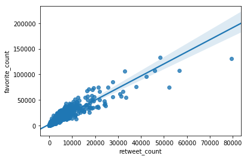

```python
#regplot method is used to plot data and a linear regression model fit,,
#There are a number of mutually exclusive options for estimating the regression model. source(geeksforgeeks)
sb.regplot(x="retweet_count", y="favorite_count", data=twitter_archive_master)
```

- ##### With correlation coefficient equals to 0.91 and a positIve strong relationship between retweet_count and favorite_count, there is definitely a relationship between these two column.

# Insight 3 & Visualization

```
Text(0.5,1,'ditribution of source')
```

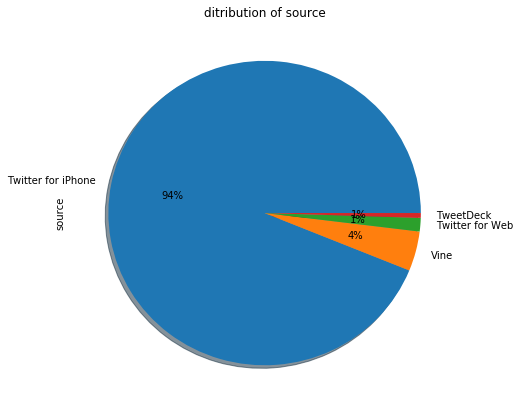

```python
#plotting the distribution of source of tweets.
plot = twitter_archive_master.source.value_counts().plot.pie(figsize=(7, 7),autopct='%.f%%', shadow=True)
plot.set_title('ditribution of source')
```

- As we can see in pie plot above, 94% of tweets in this dataset came from twitter for iPhone, which is an indicator that twitter in mobiles in general is where most of users uses the application.

## Insight 4 & Visualization

```
Text(0.5,1,'ditribution of the dog stage')
```

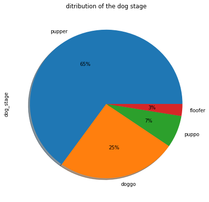

```python
#plot the distribution of dog_stage in this dataset.
plot2 = twitter_archive_master.dog_stage.value_counts().plot.pie(figsize=(7, 7),autopct='%.f%%', shadow=True)
plot2.set_title('ditribution of the dog stage')
```

- 65% of dogs are pupper dogs, and 25% are doggo dogs.

### Visualization

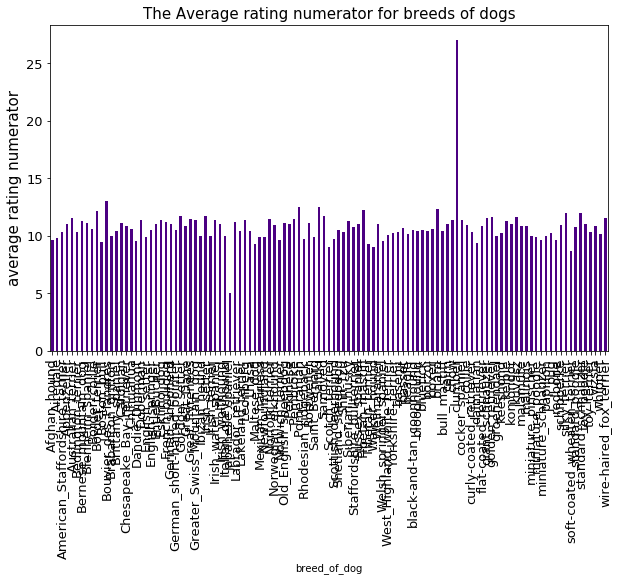

```python
#calculate the average of rating numerator for each type of breeds of dogs.
breeds_of_dog = twitter_archive_master.groupby(['breed_of_dog'])['rating_numerator'].mean().plot(kind='bar', figsize=(10,6), \
                                                                                                  color="indigo", fontsize=13);

#set the labels and title
breeds_of_dog.set_title("The Average rating numerator for breeds of dogs", fontsize=15)
breeds_of_dog.set_ylabel("average rating numerator", fontsize=15);
plt.show()
```

##### Since we have so many breeds, we need to simplify the graph in order to see it probably.

```python
#calculate the average count for each breed of dogs
twitter_archive_master['breed_of_dog'].value_counts().mean()
```

```
14.831858407079647
```

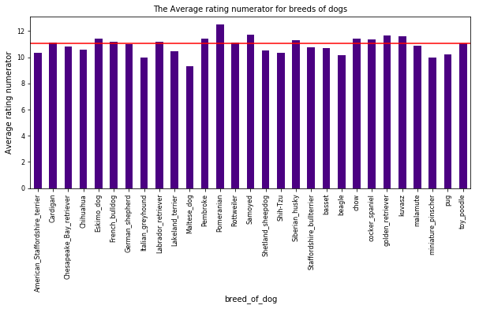

```python
#source of filter method 'https://stackoverflow.com/questions/13167391/filtering-grouped-dataframe-in-pandas'
#take only breeds that have more than 15 records
filtered_breed = twitter_archive_master.groupby(['breed_of_dog']).filter(lambda x: len(x) > 15)

#plot the average rating for each breed.
xx= filtered_breed.groupby(['breed_of_dog'])['rating_numerator'].mean().plot(kind='bar', figsize=(10,4), color="indigo", fontsize=8);

#set the labels and title
xx.set_title("The Average rating numerator for breeds of dogs", fontsize=10)
xx.set_ylabel("Average rating numerator", fontsize=10);

#calculate the average of rating for filtered_breed
mean_rating= filtered_breed['rating_numerator'].mean()

#plot a red line that represent the average rating for all breeds of dogs
plt.axhline(mean_rating, color="r");
```

**After filtering , we can see clearly the average rating for each type of breeds.**

### Insight 5

```python
twitter_archive_master.describe()
```

|  | rating_numerator | rating_denominator | favorite_count | retweet_count |
| --- | --- | --- | --- | --- |
| count | 2161.000000 | 2161.000000 | 2161.000000 | 2161.000000 |
| mean | 12.688107 | 9.990282 | 8779.167978 | 2768.202684 |
| std | 47.228923 | 0.282839 | 12081.955511 | 4659.229659 |
| min | 0.000000 | 0.000000 | 52.000000 | 0.000000 |
| 25% | 10.000000 | 10.000000 | 1909.000000 | 608.000000 |
| 50% | 11.000000 | 10.000000 | 4077.000000 | 1343.000000 |
| 75% | 12.000000 | 10.000000 | 11117.000000 | 3224.000000 |
| max | 1776.000000 | 10.000000 | 132810.000000 | 79515.000000 |

- The average favorites is 8779 whereas the retweets is 2768 which shows that users tend to press the like button more often than the retweets, which is obvious since it an account for dog’s fans and like button is a gesture to indicate you like the dog.
- The average rating numerator is 12.68/10.

```python
#saving our cleaned and merged dataset: -

#         * I comment this line to avoid saving the file multiple times.

#twitter_archive_master.to_csv('twitter_archive_master.csv', index=True)
```